# 1. LIMPIEZA Y TRANSFORMACION DE LOS DATOS

Dimensión 3 (13.28% de varianza) — dominada por: tiempo_proveedor (46.48%, r=-0.73), ventas_mes (18.77%, r=+0.47), n_clientes (14.80%, r=+0.41), compra_mensual_num (13.19%, r=-0.39)

Aquí ocurre algo interesante: los signos se contraponen. tiempo_proveedor y compra_mensual_num cargan negativo, mientras ventas_mes y n_clientes cargan positivo. Esto sugiere un eje bipolar: de un lado, subdistribuidores con relación comercial más antigua y compras grandes pero menos frecuentes; del otro, subdistribuidores con alta rotación de clientes y ventas pero relaciones más nuevas con la cooperativa y compras más pequeñas/frecuentes.

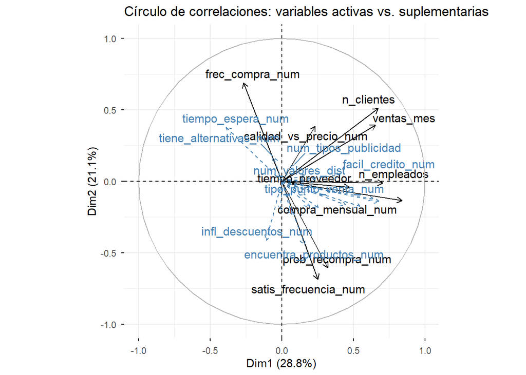

```r
# chunk3.2b2 - Círculo de correlaciones con variables suplementarias (descartadas)
# ============================================

# Variables numéricas descartadas (binarias, ordinales, conteo) que sí pueden proyectarse

vars_suplementarias <- c(
  "valor_cupo_num", "tiempo_actividad_num", "frec_urgencias_num", "tiempo_espera_num",
  "tipo_punto_venta_num", "facil_credito_num", "infl_descuentos_num", "encuentra_productos_num",
  "almacenamiento_num", "tiene_alternativas_num", "tiene_presupuesto_num", "prod_fidelidad_num",
  "marca_memorable_num", "asistencia_tecnica_num", "vehiculo_propio_num", "recomendaria_num",
  "num_valores_dist", "num_cond_perm", "num_tipos_publicidad", "num_lineas"
)
vars_suplementarias <- vars_suplementarias[vars_suplementarias %in% names(datos_numericos)]

# Dataset combinado: activas primero, suplementarias después
datos_pca_extendido <- datos_numericos[c(vars_pca, vars_suplementarias)]

# PCA con variables suplementarias (no afectan la construcción de los componentes)
pca_supl <- PCA(datos_pca_extendido,
                scale.unit = TRUE,
                graph = FALSE,
                quanti.sup = (length(vars_pca) + 1):ncol(datos_pca_extendido),
                ncp = 3)

# Círculo de correlaciones: activas (negro) vs. suplementarias (azul)
fviz_pca_var(pca_supl,
             col.var = "black",
             col.quanti.sup = "steelblue",
             repel = TRUE,
             title = "Círculo de correlaciones: variables activas vs. suplementarias")
```

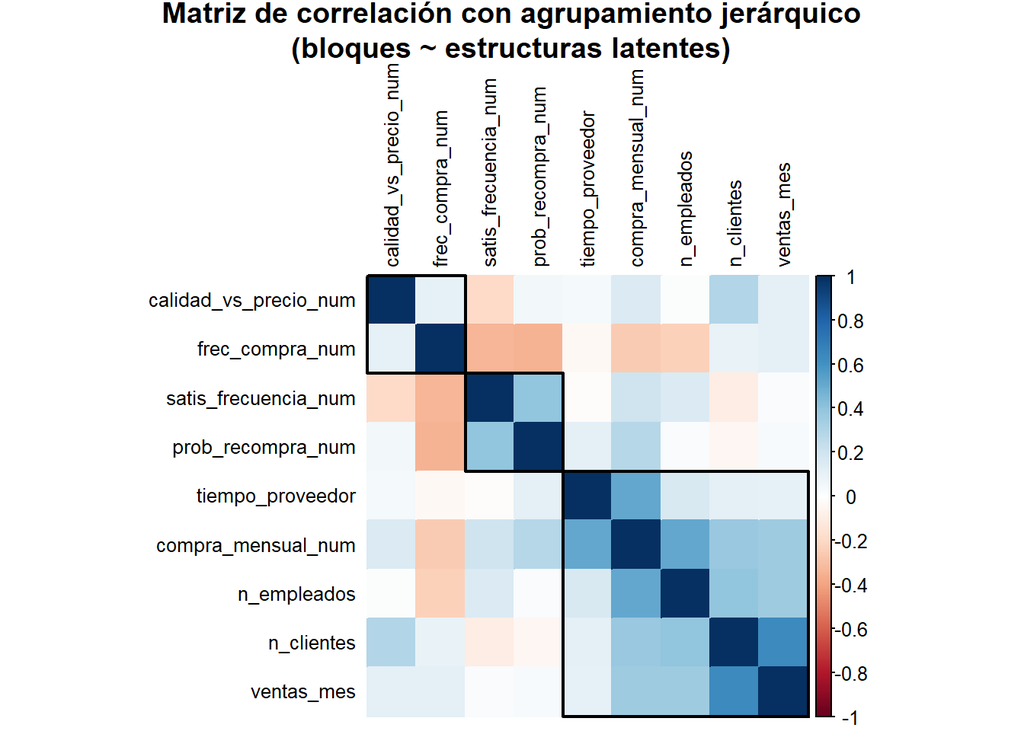

```r
# chunk3.2c - Estructuras latentes: correlaciones y ecuaciones de los componentes 2
# ============================================

library(corrplot)

# 1. MATRIZ DE CORRELACIÓN ENTRE VARIABLES ORIGINALES, AGRUPADA POR "FACTORES"
# El ordenamiento jerárquico agrupa visualmente las variables que se mueven juntas,
# lo cual debe coincidir aproximadamente con las 3 dimensiones retenidas
matriz_corr_pca <- cor(datos_prep[vars_pca], use = "pairwise.complete.obs")

corrplot(matriz_corr_pca,
         method = "color",
         order = "hclust",      # agrupa variables según similitud de correlación
         addrect = 3,           # dibuja 3 bloques ~ 3 componentes retenidos
         tl.col = "black",
         tl.cex = 0.8,
         title = "Matriz de correlación con agrupamiento jerárquico\n(bloques ~ estructuras latentes)",
         mar = c(0, 0, 2, 0))
```

```r
# 2. CORRELACIÓN ENTRE LAS DIMENSIONES (COMPONENTES) RESULTANTES
# Por construcción del PCA, las dimensiones deben ser ortogonales (correlación ≈ 0)


# 3. ECUACIONES DE LAS ESTRUCTURAS LATENTES
# Los coeficientes (b) son los loadings (autovectores) que definen cada componente
loadings_df <- as.data.frame(round(pca_result$svd$V[, 1:3], 3))
rownames(loadings_df) <- vars_pca
colnames(loadings_df) <- c("Dim1", "Dim2", "Dim3")

cat("COEFICIENTES (LOADINGS) DE CADA VARIABLE POR COMPONENTE\n")
```

```
## COEFICIENTES (LOADINGS) DE CADA VARIABLE POR COMPONENTE
```

```r
print(loadings_df)
```

```
##                         Dim1   Dim2   Dim3
## n_empleados            0.416  0.035  0.105
## n_clientes             0.371  0.327  0.385
## ventas_mes             0.374  0.214  0.433
## tiempo_proveedor       0.280  0.089 -0.682
## compra_mensual_num     0.591  0.029 -0.363
## calidad_vs_precio_num  0.098  0.286  0.035
## frec_compra_num       -0.072  0.135  0.063
## satis_frecuencia_num   0.307 -0.842  0.215
## prob_recompra_num      0.110 -0.166 -0.071
```

```r
# Construcción automática de la ecuación en formato Y = b1X1 + b2X2 + ... + bnXn + e
construir_ecuacion <- function(loadings_df, dim) {
  coefs <- loadings_df[[dim]]
  vars  <- rownames(loadings_df)
  terminos <- paste0(ifelse(coefs >= 0, "+ ", "- "), sprintf("%.3f", abs(coefs)), "\u00b7", vars)
  ecuacion <- paste(terminos, collapse = " ")
  ecuacion <- sub("^\\+ ", "", ecuacion)
  paste0(dim, "_i = ", ecuacion, " + \u03b5_i")
}

for (d in c("Dim1", "Dim2", "Dim3")) {
  cat("\n", construir_ecuacion(loadings_df, d), "\n")
}
```

```
##
##  Dim1_i = 0.416·n_empleados + 0.371·n_clientes + 0.374·ventas_mes + 0.280·tiempo_proveedor + 0.591·compra_mensual_num + 0.098·calidad_vs_precio_num - 0.072·frec_compra_num + 0.307·satis_frecuencia_num + 0.110·prob_recompra_num + ε_i
##
##  Dim2_i = 0.035·n_empleados + 0.327·n_clientes + 0.214·ventas_mes + 0.089·tiempo_proveedor + 0.029·compra_mensual_num + 0.286·calidad_vs_precio_num + 0.135·frec_compra_num - 0.842·satis_frecuencia_num - 0.166·prob_recompra_num + ε_i
##
##  Dim3_i = 0.105·n_empleados + 0.385·n_clientes + 0.433·ventas_mes - 0.682·tiempo_proveedor - 0.363·compra_mensual_num + 0.035·calidad_vs_precio_num + 0.063·frec_compra_num + 0.215·satis_frecuencia_num - 0.071·prob_recompra_num + ε_i
```

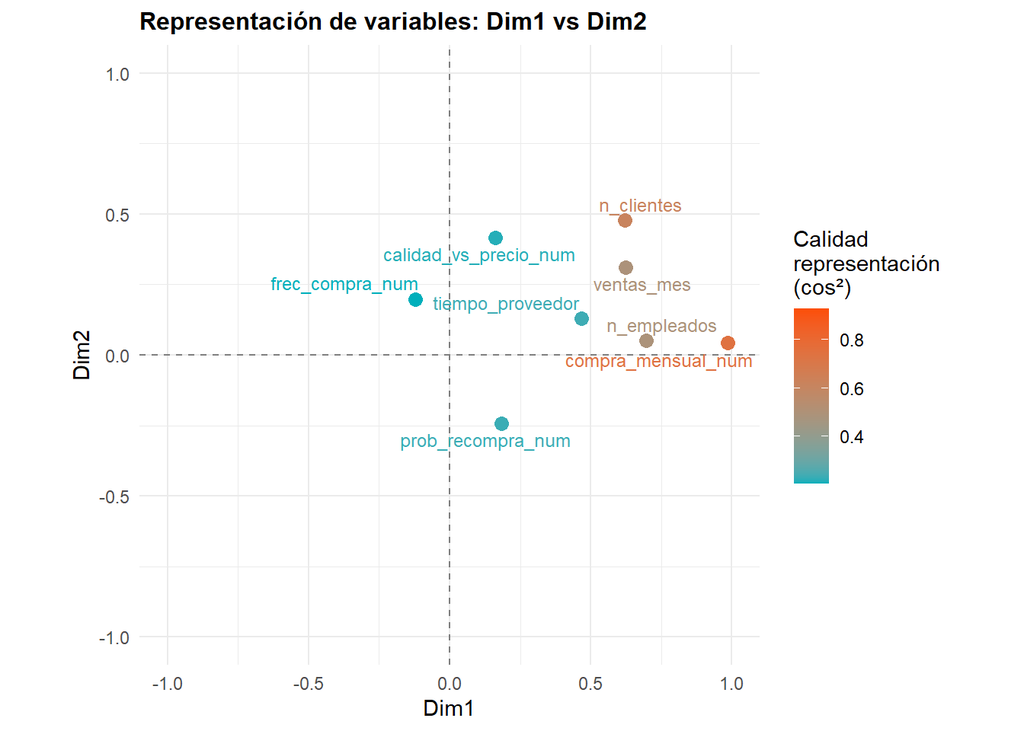

```r
# chunk3.2d - Gráfico de representación de variables (mapa factorial)
# ============================================

# 1. Extraer coordenadas y calidad de representación (cos2)
coord_completo <- as.data.frame(pca_result$var$coord[, 1:3])
cos2_completo  <- as.data.frame(pca_result$var$cos2[, 1:3])

mapa_vars <- data.frame(
  Variable = rownames(coord_completo),
  Dim1 = coord_completo$Dim.1,
  Dim2 = coord_completo$Dim.2,
  Dim3 = coord_completo$Dim.3,
  cos2_12 = cos2_completo$Dim.1 + cos2_completo$Dim.2,  # calidad de repr. en el plano 1-2
  cos2_13 = cos2_completo$Dim.1 + cos2_completo$Dim.3,
  cos2_23 = cos2_completo$Dim.2 + cos2_completo$Dim.3
)

# 2. FUNCIÓN PARA GENERAR EL MAPA FACTORIAL (estilo cuadrantes, sin círculo)
graficar_mapa_variables <- function(datos, eje_x, eje_y, cos2_col, titulo) {
  ggplot(datos, aes_string(x = eje_x, y = eje_y, color = cos2_col)) +
    geom_hline(yintercept = 0, linetype = "dashed", color = "grey50") +
    geom_vline(xintercept = 0, linetype = "dashed", color = "grey50") +
    geom_point(size = 3) +
    ggrepel::geom_text_repel(aes(label = Variable), size = 3.2, show.legend = FALSE) +
    scale_color_gradient(low = "#00AFBB", high = "#FC4E07", name = "Calidad\nrepresentación\n(cos²)") +
    xlim(-1, 1) + ylim(-1, 1) +
    coord_fixed() +
    labs(title = titulo, x = eje_x, y = eje_y) +
    theme_minimal() +
    theme(plot.title = element_text(face = "bold", size = 12))
}

# 3. GENERAR LOS TRES PLANOS FACTORIALES POSIBLES
p_dim12 <- graficar_mapa_variables(mapa_vars, "Dim1", "Dim2", "cos2_12",
                                     "Representación de variables: Dim1 vs Dim2")
p_dim13 <- graficar_mapa_variables(mapa_vars, "Dim1", "Dim3", "cos2_13",
                                     "Representación de variables: Dim1 vs Dim3")
p_dim23 <- graficar_mapa_variables(mapa_vars, "Dim2", "Dim3", "cos2_23",
                                     "Representación de variables: Dim2 vs Dim3")

print(p_dim12)
```

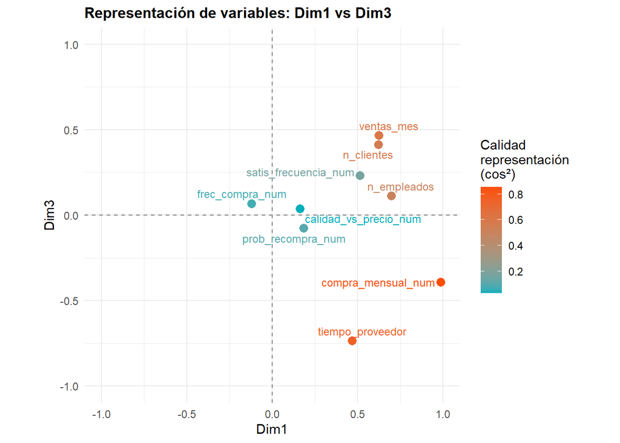

```r
print(p_dim13)
```

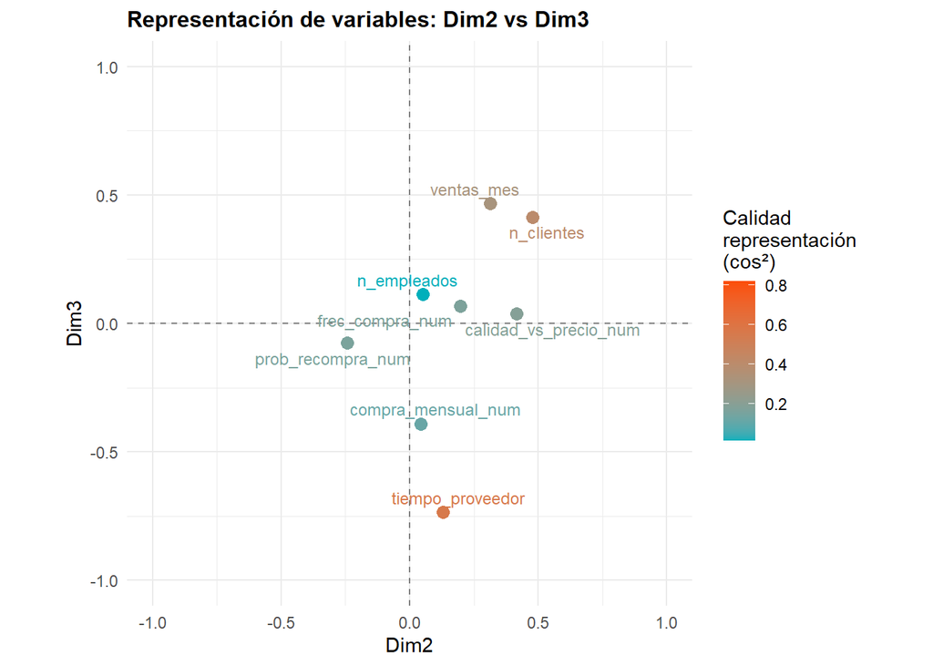

```r
print(p_dim23)
```

```r
# 4. TABLA DE CALIDAD DE REPRESENTACIÓN (cos2) POR VARIABLE Y DIMENSIÓN
cat("CALIDAD DE REPRESENTACIÓN (cos²) POR VARIABLE\n")
```

```
## CALIDAD DE REPRESENTACIÓN (cos²) POR VARIABLE
```

```r
print(round(cos2_completo, 3))
```

```
##                       Dim.1 Dim.2 Dim.3
## n_empleados           0.489 0.003 0.013
## n_clientes            0.388 0.230 0.174
## ventas_mes            0.394 0.098 0.220
## tiempo_proveedor      0.221 0.017 0.546
## compra_mensual_num    0.740 0.001 0.116
## calidad_vs_precio_num 0.029 0.189 0.002
## frec_compra_num       0.056 0.150 0.018
## satis_frecuencia_num  0.138 0.790 0.028
## prob_recompra_num     0.085 0.148 0.015
```

Interpretación del cos²

Recordemos: cos² va de 0 a 1, y representa qué tan bien está explicada esa variable específicamente por ese componente (a diferencia de contrib, que compara variables entre sí dentro de un componente, cos² mide qué tan “fiel” es la representación de esa variable individual).

Variables muy bien representadas (cos² alto, >0.5) — es decir, casi toda su varianza está capturada por un solo eje:

*compra_mensual_num* → 0.740 en Dim1 (representación casi perfecta, poca dispersión hacia otros ejes) *satis_frecuencia_num* → 0.790 en Dim2 (representación muy fuerte y aislada) *tiempo_proveedor* → 0.546 en Dim3 (razonablemente bien representada)

Variables mal representadas en estos 3 componentes (cos² bajo en todas las dimensiones):

*calidad_vs_precio_num* (0.029 / 0.189 / 0.002) *frec_compra_num* (0.056 / 0.150 / 0.018) y *prob_recompra_num* (0.085 / 0.148 / 0.015)

Este último grupo es importante mencionarlo: son variables cuya varianza no queda bien capturada por los 3 componentes retenidos — es decir, tienen un comportamiento más disperso o independiente que no se resume bien en este espacio reducido. Vale la pena señalarlo como una limitación menor del modelo (o una oportunidad: podrían mantenerse como variables suplementarias en el perfilado de clústeres en lugar de depender solo de las 3 dimensiones).

Aunque, El costo de un 4to componente sería alto en interpretabilidad, y bajo en beneficio. Ya identificamos qué representaría ese posible 4to eje: básicamente el bloque de calidad_vs_precio_num + frec_compra_num que vimos en la matriz de correlación. Pero mira sus comunalidades totales (suma de cos² en las 3 dimensiones actuales):

calidad_vs_precio_num: 0.029+0.189+0.002 = 0.22 de varianza total explicada frec_compra_num: 0.056+0.150+0.018 = 0.22

Son variables con baja comunalidad general, no solo mal representadas en estos 3 ejes — es decir, tienen bastante varianza idiosincrática/ruido que ni un 4to componente garantizaría capturar bien. Añadir un componente solo para “rescatar” dos variables débiles rompe la regla de parsimonia sin garantía de mejora real.

```r
#chunk3.3
#  Extraer coordenadas
# ============================================

# Cargar número de componentes
if(file.exists("checkpoints/n_componentes_usar.rds")) {
  n_componentes_usar <- readRDS("checkpoints/n_componentes_usar.rds")
} else {
  n_componentes_usar <- sum(pca_result$eig[,1] > 1)
}

# Extraer coordenadas
datos_pca_coord <- as.data.frame(pca_result$ind$coord[, 1:n_componentes_usar])
names(datos_pca_coord) <- paste0("PC", 1:n_componentes_usar)
datos_pca_coord$id <- 1:nrow(datos_pca_coord)

# Dataset para clustering (sin ID)
datos_cluster <- datos_pca_coord %>% select(-id)

cat("Dimensiones para clustering:", nrow(datos_cluster), "x", ncol(datos_cluster), "\n")
```

```
## Dimensiones para clustering: 99 x 3
```